# pca_analysis

```python
import pandas as pd
from sklearn.decomposition import PCA
from sklearn.preprocessing import StandardScaler
from sklearn.impute import KNNImputer
import umap
import matplotlib.pyplot as plt
from mpl_toolkits.mplot3d import Axes3D
import matplotlib.cm as cm

from sklearn.cluster import KMeans

#this version of sklearn was throwing a bunch of runtime warnings, so this filters them out so the HTML notebook is still readable
import warnings
warnings.filterwarnings('ignore', category=RuntimeWarning)
```

```python
#read in data
data = pd.read_csv('pdc_joined_all_cancer_types.txt')
print(data.shape)
data.head()
```

```
(678, 12172)
```

|  | aliquot_submitter_id | A1BG | A2M | A2ML1 | AAAS | AACS | AADAT | AAED1 | AAGAB | AAK1 | ... | ZNF302 | ZNF391 | ZNF404 | ZNF43 | ZNF431 | ZNF438 | ZNF527 | ZNF689 | ZNF707 | ZNF93 |
| --- | --- | --- | --- | --- | --- | --- | --- | --- | --- | --- | --- | --- | --- | --- | --- | --- | --- | --- | --- | --- | --- |
| 0 | 263d3f-I | 1.5591 | 1.4396 | 0.0470 | 0.3621 | 0.5217 | NaN | 0.4883 | -0.2769 | 0.0816 | ... | NaN | NaN | NaN | NaN | NaN | NaN | NaN | NaN | NaN | NaN |
| 1 | A2-A0CM-01A | -0.2842 | -0.1318 | 1.5785 | 0.0939 | -0.8186 | 0.3095 | NaN | -0.2740 | 0.0278 | ... | NaN | NaN | NaN | NaN | NaN | NaN | NaN | NaN | NaN | NaN |
| 2 | A2-A0D0-01A | 0.8159 | 0.7543 | -1.6186 | 1.4300 | -0.1409 | NaN | -2.6694 | 0.0144 | -0.1223 | ... | NaN | NaN | NaN | NaN | NaN | NaN | NaN | NaN | NaN | NaN |
| 3 | A2-A0D1-01A | 1.4509 | 1.2298 | -0.0068 | 1.0839 | -0.5940 | 2.4772 | NaN | 0.9372 | 0.4364 | ... | NaN | NaN | NaN | NaN | NaN | NaN | NaN | NaN | NaN | NaN |
| 4 | A2-A0D2-01A | 0.0133 | -0.0624 | -0.4037 | 0.3813 | -0.5412 | 0.7456 | 0.3724 | -0.2081 | 0.0353 | ... | NaN | NaN | NaN | NaN | NaN | NaN | NaN | NaN | NaN | NaN |

5 rows × 12172 columns

```python
#print column names, need review which clinical feature are present
#for col in data.columns:
   # print(col)
```

```python
# remove clinical features, as they represent the outcomes we expect to be associated with the proteomic profiles
clinical_cols = ['case_submitter_id',
                 'sample_type',
                 'case_id',
                 'disease_type',
                 'primary_site',
                 'pdc_study_id',
                 'cancer_type',
                 'ethnicity',
                 'gender',
                 'race',
                 'vital_status',
                 'days_to_birth',
                 'days_to_death',
                 'tobacco_smoking_status',
                 'alcohol_history',
                 'years_smoked',
                 'pack_years_smoked',
                 'age_years']
protein_df = data.drop(columns=clinical_cols)

#convert all protein columns to numeric (some are object due to missing values)
protein_df = protein_df.apply(pd.to_numeric, errors='coerce')
```

```python
#impute and. scale
imputer = KNNImputer(n_neighbors=5)
imputed_data = imputer.fit_transform(protein_df)
scaled_data = StandardScaler().fit_transform(imputed_data)

#write out fully prepped data
scaled_df = pd.DataFrame(scaled_data)
scaled_df.to_csv('pdc_proteomics_scaled_imputed.csv', index=False)
```

```python
#select enough components to explain 95% of the variance, and we'll see how many components that is.
pca = PCA(n_components=.95)
pca.fit(scaled_data)
print(pca.n_components_)
```

```
427
```

427 is still a lot of features- the dataset has only 678. According to the references of its Wikipedia article, the debate about the "one in ten rule" for 'events-per-variable' appears to be ongoing. Proteomics is discussed as a field with particularly high-dimensional data for which desireable EPV ratios may simply not be attainable due to the limited number of patients typically available in a cohort. https://www.nature.com/articles/s41591-026-04337-2 https://pmc.ncbi.nlm.nih.gov/articles/PMC4777663/

This is a really fascinating and intricate problem; for the sake of efficiency in this project, let's just try to find something reasonable without losing too much variance.

```python
#select enough components to explain 95% of the variance, and we'll see how many components that is.
pca = PCA(n_components=.85)
pca.fit(scaled_data)
print(pca.n_components_)
```

```
227
```

```python
pca = PCA(n_components=.75)
pca.fit(scaled_data)
print(pca.n_components_)
```

```
125
```

Okay, 125 is workable, possibly.  
We have 4 different types of cancer in this set, and we would expect biologically the protein expression profiles to at least somewhat cluster by type. Let's run the transform, and then visualize the main PCs

Visualization resources:  
https://python-graph-gallery.com/515-intro-pca-graph-python/ .  
https://plotly.com/python/pca-visualization/ .

3-d plotting extension with matplotlib.  
https://matplotlib.org/stable/api/_as_gen/mpl_toolkits.mplot3d.axes3d.Axes3D.scatter.html#mpl_toolkits.mplot3d.axes3d.Axes3D.scatter.

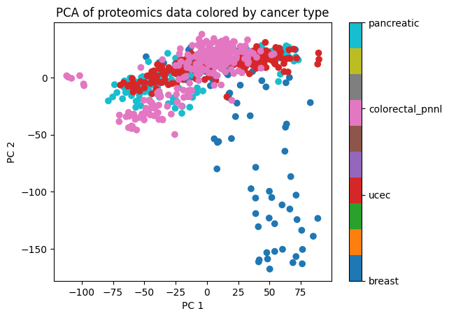

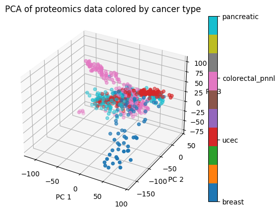

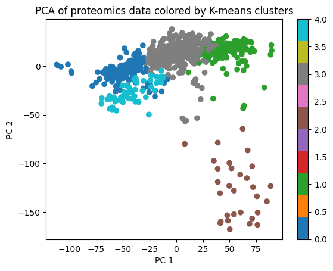

```python
#TODO- fix colorbars to only show the appropirate number of colors

pca_transform = pca.fit_transform(scaled_data)

#plot PC 1 and 2 colored by cancer type
plt.scatter(pca_transform[:, 0], pca_transform[:, 1], c=data['cancer_type'].astype('category').cat.codes, cmap='tab10')
plt.title('PCA of proteomics data colored by cancer type')
plt.xlabel('PC 1')
plt.ylabel('PC 2')
cbar = plt.colorbar()
cbar.set_ticks(range(len(data['cancer_type'].unique())))
cbar.set_ticklabels(data['cancer_type'].unique())
plt.show()


#3-d  plot adding the 3rd component
fig = plt.figure()
ax = fig.add_subplot(111, projection='3d')
ax.scatter(pca_transform[:, 0], pca_transform[:, 1], pca_transform[:, 2], c=data['cancer_type'].astype('category').cat.codes, cmap='tab10')
ax.set_title('PCA of proteomics data colored by cancer type')
ax.set_xlabel('PC 1')
ax.set_ylabel('PC 2')
ax.set_zlabel('PC 3')
cbar = fig.colorbar(ax.collections[0])
cbar.set_ticks(range(len(data['cancer_type'].unique())))
cbar.set_ticklabels(data['cancer_type'].unique())
plt.show()



#what if we cluster with k-means?
kmeans = KMeans(n_clusters=5, random_state=42).fit(pca_transform)
clusters = kmeans.labels_

#plot PC 1 and 2 colored by K-means clusters
plt.scatter(pca_transform[:, 0], pca_transform[:, 1], c=clusters, cmap='tab10')
plt.title('PCA of proteomics data colored by K-means clusters')
plt.xlabel('PC 1')
plt.ylabel('PC 2')
plt.colorbar()
plt.show()
```

```python
#print out the proteins with the highest signal from the PCA, and their relative contributions to the PCA signal
feature_cols = protein_df.columns[protein_df.notna().any(axis=0)]
loading_scores = pd.Series(pca.components_[0], index=feature_cols)
sorted_loading_scores = loading_scores.abs().sort_values(ascending=False)
top_20_proteins = sorted_loading_scores.head(20).index.values
top_20_loading_scores = loading_scores[top_20_proteins]
#comebine into a dataframe
top_20_df = pd.DataFrame({'protein': top_20_proteins, 'loading_score': top_20_loading_scores})

print(top_20_df)
```

```
           protein  loading_score
DPYSL2      DPYSL2       0.023343
LUM            LUM       0.023076
GSN            GSN       0.022649
TLN1          TLN1       0.022534
CNRIP1      CNRIP1       0.022477
SEPT2        SEPT2       0.022444
C8orf88    C8orf88       0.022438
EHD3          EHD3       0.022389
DCN            DCN       0.022367
MYL9          MYL9       0.022327
PDLIM7      PDLIM7       0.022285
EHD2          EHD2       0.022168
DPYSL3      DPYSL3       0.022131
MYL12A      MYL12A       0.022118
AMBP          AMBP       0.022099
SERPINC1  SERPINC1       0.022077
VCL            VCL       0.022063
LAMA4        LAMA4       0.022054
TLN2          TLN2       0.022051
INHBE        INHBE       0.022008
```

```python
var_pc1 = pca.explained_variance_ratio_[0]
var_pc2 = pca.explained_variance_ratio_[1]
var_pc3 = pca.explained_variance_ratio_[2]
print(var_pc1, var_pc2, var_pc3 )
```

```
0.1209750149551611 0.08779412378995068 0.07727664213337115
```